# Propensity Scores

Author

Jan-Michael Becker

Published

March 9, 2026

# Introduction

In this document, we will discuss the concept of propensity scores and how to estimate them.

The propensity score measures the probability of being treated conditional on the observed covariates and is defined as:

$$p(X_i)=P(T_i=1|X_i)$$

In an ideal randomized experiment with two equally sized groups (i.e., $T_i ∈\{0, 1\} ⊥ X_i$), the propensity score is constant at 0.5, since the probability of being treated is equal to the probability of being untreated. More generally, for randomized $T_i$, we have $p(X_i) = p_0 ∈ (0,1)$, where $p_0$ is the true propensity score ranging between zero and one, depending on the group sizes.

However, in practice, the actual propensity score even for randomized experiments is rarely constant because randomization is rarely perfect in finite samples. Thus, we usually do not know the propensity scores $p(X_i)$ but can estimate $\hat{p}(X_i)$. Many methods are available to estimate the propensity score, including logistic regression, classification trees, and other machine learning algorithms.

One use of the propensity score is to balance the covariates between treatment and control groups. By matching or weighting observations based on their estimated propensity scores, we can create comparable groups of treated and untreated individuals in terms of their observed covariates. This reduces the bias due to confounding and improves the precision of the treatment effect estimate. We discuss this in more detail in the “matching” lecture.

Another use of the propensity score is to assess how close a given dataset is to an ideal randomized experiment. Looking at the distribution and variability of the (estimated) propensity scores gives a measure of how far we are from a randomized experiment. If the propensity scores are well balanced between treatment and control groups and tightly distributed around 0.5 (for equally sized groups), we can have more confidence in the validity of the treatment effect estimate. If the propensity scores are imbalanced, we may need to adjust for more covariates or consider alternative methods for estimating the treatment effect.

The propensity score can even be used to estimate individual treatment effects. These estimates are extremely noisy and not very much practically relevant, but can be used for techniques that try to uncover treatment effect heterogeneity.

In this document, we want to look at the basic of propensity scores and how to estimate them using logistic regression. We will first use a DGP with randomized `T`. Afterwards we will use the DGP where `T` depends on `X` (i.e., selection on observables) scenario.

# Randomized experiment

We will reuse the DGP from our first document (potential outcome framework).

```r
# Set seed for reproducibility
set.seed(13579)

# Define the number of observations
n <- 10000

# Generate treatment assignment
# Treatement assignment here will be random
T <- sample(0:1, size = n, replace = TRUE)

# Generate covariates
X1 <- rnorm(n, mean = 50, sd = 10)
X2 <- rpois(n, lambda = 5)
X3 <- sample(c("Yes", "No"), size = n, replace = TRUE)

X3 <- ifelse(X3 == "Yes", 1, 0)

# Generate potential outcomes with covariates
E_y1 = 100
E_y0 = 80
Y1 <- E_y1 + 0.5*X1 - 2*X2 + 3*X3 + rnorm(n, mean = 0, sd = 5)
Y0 <- E_y0 + 0.5*X1 - 2*X2 + 3*X3 + rnorm(n, mean = 0, sd = 5)

# The true average treatment effect / causal effect
tau <- mean(Y1) - mean(Y0)

# Calculate the observed outcome based on treatment assignment
Y <- Y0 + (Y1-Y0)*T

# Create a data frame
data <- data.frame(T, Y, Y1, Y0, X1, X2, X3)
```

We can estimate the propensity score in R using the `glm()` function to fit a logistic regression model. The propensity scores are the predicted outcomes of the logistic regression with the treatment assignment `T` as dependent variable and the covariates `X` as predictors. These predicted outcomes are the estimated probabilities of treatment assignment given the covariates.

We can then estimate the propensity scores for each observation using the `predict()` function and specify `type = "response"` to get the predicted probabilities of being treated. Finally, we can display a plot of the distribution using a histogram.

```r
# Fit a logistic regression model for the propensity score
model_prop <- glm(T ~ X1 + X2 + X3, data = data, family = binomial())

# Estimate the propensity scores for each observation
prop_scores <- predict(model_prop, type = "response")

# Display summary statistics of the propensity scores
summary(prop_scores)
```

```
   Min. 1st Qu.  Median    Mean 3rd Qu.    Max.
 0.4739  0.4988  0.5037  0.5037  0.5085  0.5338
```

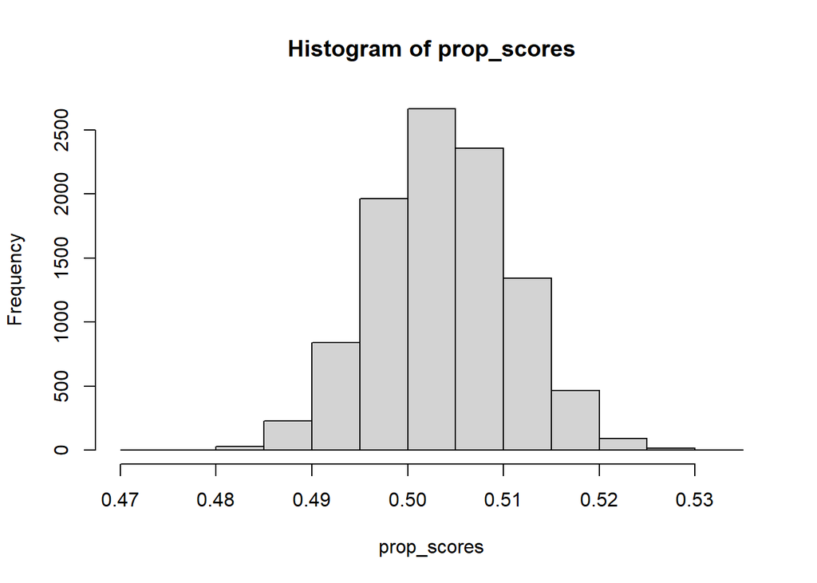

```r
hist(prop_scores)
```

We can see that the propensity scores are tightly centered around 0.5 with rather small variability. This indicates that the treatment assignment is more or less independent of the covariates. All individuals have an almost 50/50 chance of being selected into treatment.

*Note:* A constant propensity score of 0.5 would indicate perfect independence of the covariates (e.g., randomization), which however is unusual for finite samples.

**Important:** We are always estimating the propensity scores based on covariates. Thus, it only tells us something about the covariates (X) that are observed. It cannot tell us whether T depends on some covariates that are not observed (i.e., whether we have selection on unobservables).

# Selection effects

We will now re-use a modified version of the DGP from our lecture 3 (unconfoundedness document).

```r
rm(list = ls())

# Set seed for reproducibility
set.seed(16579)

# Define the number of observations
n <- 10000

# Generate covariates
X1 <- round(rnorm(n, mean = 50, sd = 10),0)
X2 <- rpois(n, lambda = 5)
X3 <- sample(c("Yes", "No"), size = n, replace = TRUE)

X3 <- ifelse(X3 == "Yes", 1, 0)

# Generate treatment assignment
# Treatement assignment will be dependent on X1, X2, X3
# Create a linear combination of covariates to form a log-odds for T
log_odds_T <- -1.2 - 0.1 * X1 + 1 * X2 + 2 * X3 + rnorm(n, mean = 0, sd = 1)

# Calculate the probability of T being 1 using the logistic function
prob_T_1 <- 1 / (1 + exp(-log_odds_T))

# Generate T as binary treatment assignment (0 or 1) based on the probabilities
T <- rbinom(n, 1, prob_T_1)

# Generate potential outcomes with covariates
E_y1 = 1520
E_y0 = 1500
Y1 <- E_y1 - 10*log(X1) + 0.2*X1^2 - 2*X2 + 0.5*X2^2 - 0.5*X2^3 + 120*X3 + rnorm(n, mean = 0, sd = 5)
Y0 <- E_y0 - 10*log(X1) + 0.2*X1^2 - 2*X2 + 0.5*X2^2 - 0.5*X2^3 + 120*X3 + rnorm(n, mean = 0, sd = 5)

# The true average treatment effect / causal effect
tau <- mean(Y1) - mean(Y0)

# Calculate the observed outcome based on treatment assignment
Y <- round(Y0 + (Y1-Y0)*T,0)

# Create a data frame
data2 <- data.frame(T, Y, Y1, Y0, X1, X2, X3)

data2.export <- data2[,-c(3,4)]

colnames(data2.export) <- c("Discount","Sales", "Age", "Prev_Purch", "Loyalty_card")

write.table(data2.export, "Matching_example_data.csv", sep = ";", row.names = FALSE)
```

## The propensity score model

We again estimate the propensity score in R using the `glm()` function to fit a logistic regression model.

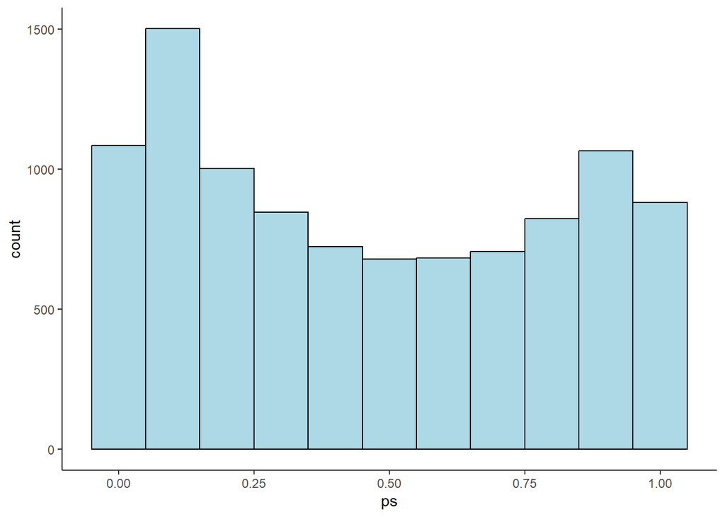

```r
# Fit a logistic regression model for the propensity score
model_prop <- glm(T ~ X1 + X2 + X3, data = data2, family = binomial())

# Estimate the propensity scores for each observation
data2$ps <- predict(model_prop, type = "response")

# Display the distribution of propensity scores
ggplot(data2, aes(x = ps)) + geom_histogram(binwidth = .1, fill = "light blue", color = "black") + theme_classic()
```

```r
mean(data2$ps)
```

```
[1] 0.4642
```

While the propensity scores are still centered around 0.5 (i.e., indicating that treatment and non-treatment are distributed equally), we see that they now have a much wider spread. In fact, they cover the whole interval between zero and one. Depending on the covariates `X` some individuals have very high or low probability of being selected.

We can also see that the propensity scores are different for the treated and the control group. The propensity of being selected into treatment based on the X is higher for the treatment group than the control group. This indicates strong selection effects.

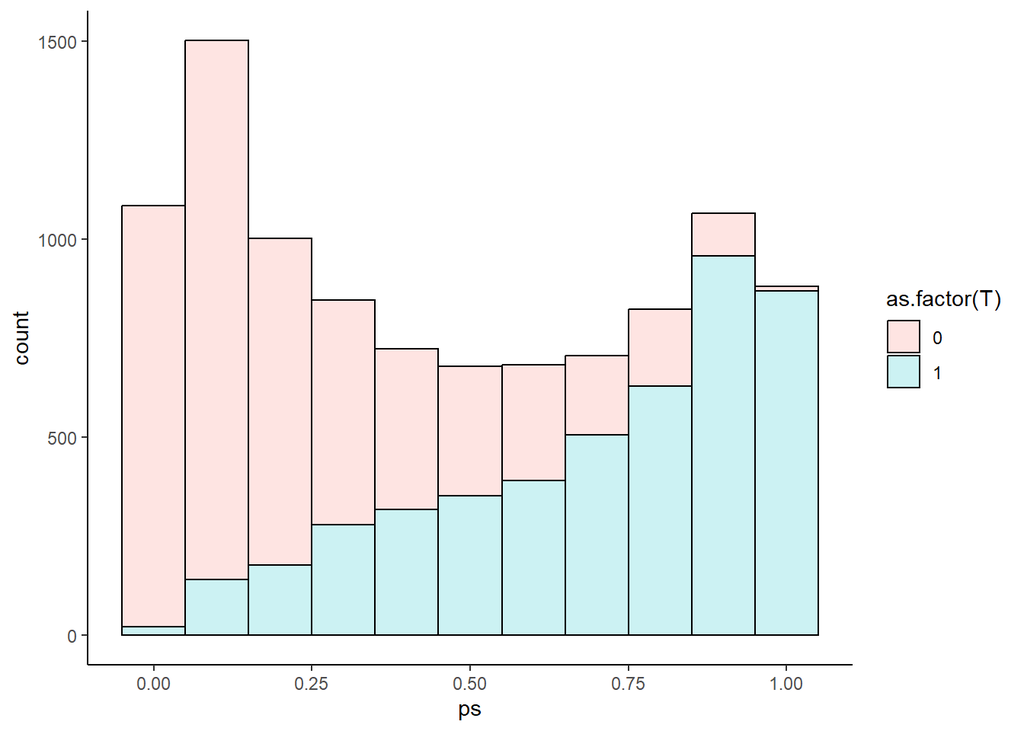

```r
# Create bins for propensity scores
breaks <- c(0, seq(0.1, 0.9, by = 0.1), 1)
propensity_bins <- cut(data2$ps, breaks = breaks)

# Create a table of propensity score to actual assignment
propensity_table <- as.data.frame.matrix(table(propensity_bins, T))
colnames(propensity_table) <- c("Control (T=0)", "Treated (T=1)")

ggplot(data2, aes(x = ps, fill=as.factor(T))) + geom_histogram(binwidth = .1, alpha = 0.2, color = "black") + theme_classic()
```

```r
# Print the table
kable(propensity_table)
```

|  | Control (T=0) | Treated (T=1) |
| --- | --- | --- |
| (0,0.1] | 1827 | 94 |
| (0.1,0.2] | 1070 | 157 |
| (0.2,0.3] | 637 | 229 |
| (0.3,0.4] | 471 | 277 |
| (0.4,0.5] | 395 | 349 |
| (0.5,0.6] | 320 | 374 |
| (0.6,0.7] | 232 | 461 |
| (0.7,0.8] | 187 | 523 |
| (0.8,0.9] | 170 | 789 |
| (0.9,1] | 49 | 1389 |

The table and the previous chart show that there is overlap / common support, but that the overlap is not very large for many of the extreme observations.

To assess the quality of the propensity score model it is usually advisable to look at the confusion matrix of the treatment predictions to assess the quality of the classification model:

```r
# Make predictions
predicted_classes <- ifelse(data2$ps >= 0.5, 1, 0)

# Create the confusion matrix
kable(table(data2$T, predicted_classes)/n)
```

|  | 0 | 1 |
| --- | --- | --- |
| 0 | 0.4400 | 0.0958 |
| 1 | 0.1106 | 0.3536 |

Here, the predictive model seems to be quite good, with relatively high accuracy, precision, and recall.

## Estimating the treatment effect - Regression adjustment

Now, we try to estimate the treatment effect. From lecture 3, we know that the effect is bias in this scenario as we have selection effects.

```r
# Run a linear regression without covariates to estimate the naive treatment effect
lm.model <- lm(Y ~ T, data = data2)

# Print the summary of the regression output
tab_model(lm.model)
```

|  | Y |  |  |
| --- | --- | --- | --- |
| Predictors | Estimates | CI | p |
| (Intercept) | 2027.29 | 2021.22 – 2033.36 | **<0.001** |
| T | -150.94 | -159.85 – -142.03 | **<0.001** |
| Observations | 10000 |  |  |
| R<sup>2</sup> / R<sup>2</sup> adjusted | 0.099 / 0.099 |  |  |

The effect is heavily biased because of the selection effects. The true effect is 20.194 but the estimated effect from this simple linear regression without further controls is -150.936.

Next, we attempt to do regression adjustment. Regression adjustment assumes linear dependencies among all variables. This assumption is violated in this case, but we want to see what happens.

```r
# Run a linear regression with covariates to estimate the treatment effect
lm.model <- lm(Y ~ T + X1+X2+X3, data = data2)

# Print the summary of the regression output
tab_model(lm.model)
```

|  | Y |  |  |
| --- | --- | --- | --- |
| Predictors | Estimates | CI | p |
| (Intercept) | 1129.86 | 1122.55 – 1137.18 | **<0.001** |
| T | 32.72 | 29.41 – 36.04 | **<0.001** |
| X1 | 19.94 | 19.81 – 20.08 | **<0.001** |
| X2 | -49.67 | -50.37 – -48.97 | **<0.001** |
| X3 | 118.87 | 116.20 – 121.54 | **<0.001** |
| Observations | 10000 |  |  |
| R<sup>2</sup> / R<sup>2</sup> adjusted | 0.926 / 0.926 |  |  |

This estimate is still biased (not as worse as before), because we are not correctly representing the true outcome model (which includes nonlinearities).

## Estimating the treatment effect - Inverse propensity weighting (IPW)

```r
# Compute the inverse propensity weights (IPW)
data2$ipw <- (data2$T - data2$ps)/(data2$ps*(1 - data2$ps))
data2$ipw <- (data2$T / data2$ps)-((1 - data2$T)/(1 - data2$ps))

# Compute the IPW estimate
ATE.ipw <- mean(data2$Y*data2$ipw)
ATE.ipw
```

```
[1] 10.32108
```

```r
# With additional truncation of the propensity scores for stability
data2$ps_t  <- pmax(0.001, pmin(0.999, data2$ps))
data2$ipw_t <- (data2$T - data2$ps_t)/(data2$ps_t*(1-data2$ps_t))

ATE.ipw_t <- mean(data2$Y*data2$ipw_t)
ATE.ipw_t
```

```
[1] 10.3219
```

Here, the IPW is also quite a bit off, regardless of truncated or untruncated calculation. The problem is that the IPW has quite large sampling variance and thus on finite samples you may observe some deviations from the true estimate.

```r
# There is an alternative way to calculate the IPW using a different N
# In the previous we divided by N (i.e., mean is equal to sum*(1/N))
# However, in finite samples the weights typically do not sum to N, thus the alternative estimator uses the sum of weights as denominator

ATE.ipw <- sum(data2$Y*(data2$T / data2$ps))*(1/n) - sum(data2$Y*((1 - data2$T)/(1 - data2$ps)))*(1/n)
ATE.ipw
```

```
[1] 10.32108
```

```r
ATE.ipw_alt <- sum(data2$Y*(data2$T / data2$ps))*(1/sum((data2$T / data2$ps))) - sum(data2$Y*((1 - data2$T)/(1 - data2$ps)))*(1/sum(((1 - data2$T)/(1 - data2$ps))))

# We get the same estimate when using the absolute weights in a weighted regression
lm.ipw <- lm(formula = Y ~ T, data = data2, weights = abs(ipw))
tab_model(lm.ipw)
```

|  | Y |  |  |
| --- | --- | --- | --- |
| Predictors | Estimates | CI | p |
| (Intercept) | 1951.20 | 1944.37 – 1958.03 | **<0.001** |
| T | 15.35 | 5.69 – 25.01 | **0.002** |
| Observations | 10000 |  |  |
| R<sup>2</sup> / R<sup>2</sup> adjusted | 0.001 / 0.001 |  |  |

```r
# The advantage is that this gives us standard errors, but they are still too small

# Estimating the IPW through a ready made package which also include inference statistics
ipw.out <- weightit(T ~ X1 + X2 + X3, data = data2, method="glm")
lm.ipw <- lm_weightit(Y ~ T, data = data2, weightit = ipw.out)
summary(lm.ipw, ci = TRUE)
```

```
Call:
lm_weightit(formula = Y ~ T, data = data2, weightit = ipw.out)

Coefficients:
            Estimate Std. Error z value Pr(>|z|)   2.5 %  97.5 %
(Intercept)  1951.20      16.26 120.032   <1e-06 1919.34 1983.06 ***
T              15.35      17.29   0.888    0.375  -18.54   49.24
Standard error: HC0 robust (adjusted for estimation of weights)
```

## Estimating the treatment effect - Propensity score matching

```r
# Perform propensity score matching using the MatchIt package
psm.out <- matchit(T ~ X1 + X2 + X3, data = data2, method = "nearest", distance = "glm", replace = TRUE)

psm.out
```

```
A `matchit` object
 - method: 1:1 nearest neighbor matching with replacement
 - distance: Propensity score
             - estimated with logistic regression
 - number of obs.: 10000 (original), 6259 (matched)
 - target estimand: ATT
 - covariates: X1, X2, X3
```

```r
summary(psm.out)
```

```
Call:
matchit(formula = T ~ X1 + X2 + X3, data = data2, method = "nearest",
    distance = "glm", replace = TRUE)

Summary of Balance for All Data:
         Means Treated Means Control Std. Mean Diff. Var. Ratio eCDF Mean
distance        0.6999        0.2600          1.7000     1.1686    0.2835
X1             47.5567       52.2322         -0.4785     1.0344    0.0640
X2              6.2529        3.8464          1.1857     1.4254    0.1504
X3              0.6387        0.3938          0.5099          .    0.2449
         eCDF Max
distance   0.5867
X1         0.1940
X2         0.4674
X3         0.2449

Summary of Balance for Matched Data:
         Means Treated Means Control Std. Mean Diff. Var. Ratio eCDF Mean
distance        0.6999        0.6998          0.0002     0.9955    0.0018
X1             47.5567       47.2938          0.0269     1.0411    0.0092
X2              6.2529        6.2258          0.0134     0.9752    0.0075
X3              0.6387        0.6258          0.0269          .    0.0129
         eCDF Max Std. Pair Dist.
distance   0.0269          0.0014
X1         0.0343          0.3519
X2         0.0295          0.2441
X3         0.0129          0.2960

Sample Sizes:
              Control Treated
All           5358.      4642
Matched (ESS)  187.51    4642
Matched       1617.      4642
Unmatched     3741.         0
Discarded        0.         0
```

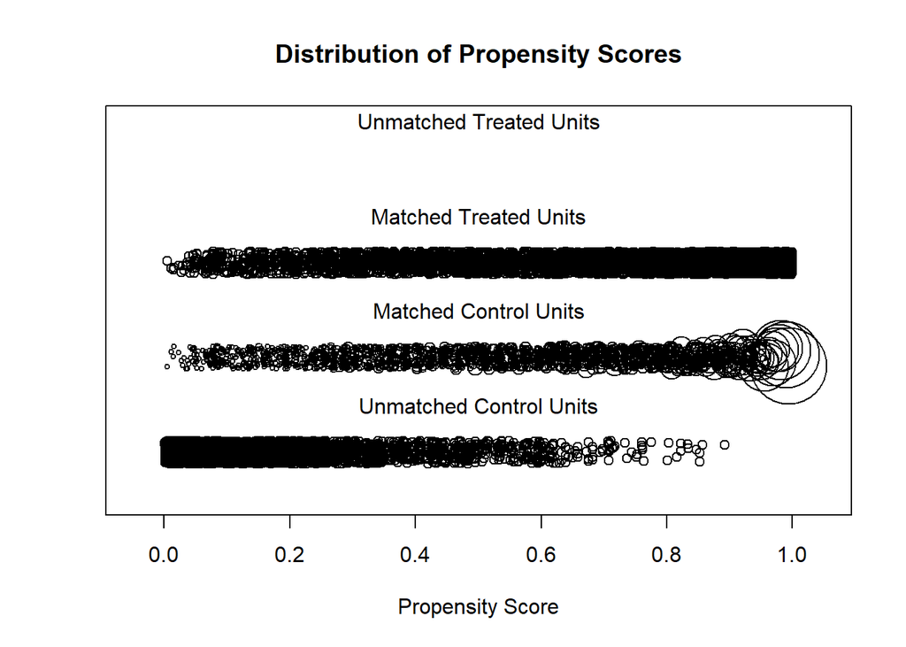

```r
plot(psm.out, type = "jitter", interactive = FALSE)
```

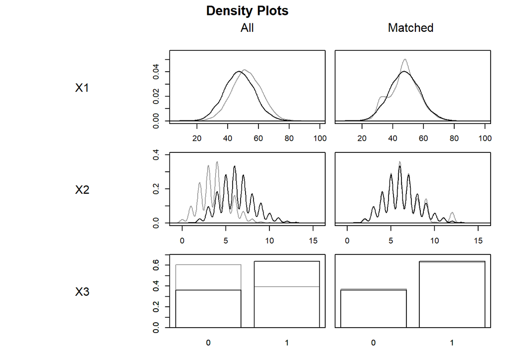

```r
plot(psm.out, type = "density", interactive = FALSE, which.xs = ~X1 + X2 + X3)
```

```r
m.data <- match.data(psm.out)

lm.match <- lm(Y ~ T, data = m.data, weights = weights)

tab_model(lm.match)
```

|  | Y |  |  |
| --- | --- | --- | --- |
| Predictors | Estimates | CI | p |
| (Intercept) | 1848.50 | 1836.66 – 1860.34 | **<0.001** |
| T | 27.86 | 14.11 – 41.61 | **<0.001** |
| Observations | 6259 |  |  |
| R<sup>2</sup> / R<sup>2</sup> adjusted | 0.003 / 0.002 |  |  |

## Estimating the treatment effect - Augmented inverse propensity weighting (AIPW)

In the following, I will outline the AIPW estimator and show that the three equations from the slides provide the same estimate and thereby how the AIPW estimator can be decomposed.

The first equation is the one that we typically find in the literature.

```r
#########################################################
# Variant 1: Two learner (T-learner)  for outcome model
# Outcome model in treatment and control is allowed to be different
#########################################################
# Compute the double robust AIPW estimate
lm.mu0 <- lm(Y ~ X1+X2+X3, data = data2[data2$T==0,])
lm.mu1 <- lm(Y ~ X1+X2+X3, data = data2[data2$T==1,])

mu0 <- predict(lm.mu0, newdata = data2)
mu1 <- predict(lm.mu1, newdata = data2)

ATE.aipw <- mean(mu1 + (data2$T/data2$ps)*(data2$Y-mu1)) - mean(mu0 + ((1-data2$T)/(1-data2$ps))*(data2$Y-mu0))

ATE.aipw
```

```
[1] 23.96138
```

```r
#########################################################
# Variant 2: Single learner (S-learner) for outcome model
# Outcome model in treatment and control is the same
#########################################################

# Standard linear regression for the outcome
lm.mu <- lm(Y ~ T + X1 + X2 + X3, data = data2)

mu1 <- predict(lm.mu, newdata = transform(data2, T = 1))
mu0 <- predict(lm.mu, newdata = transform(data2, T = 0))

ATE.aipw <- (1/n)*sum(mu1 + (data2$T/data2$ps)*(data2$Y-mu1)) - (1/n)*sum(mu0 + ((1-data2$T)/(1-data2$ps))*(data2$Y-mu0))

ATE.aipw
```

```
[1] 23.91004
```

```r
# We can also do the mean later to be able to show the distribution of aipw estimates
# This basically calculates an individual respondent's treatment effect
data2$aipw <- (mu1 + (data2$T/data2$ps)*(data2$Y-mu1)) - (mu0 + ((1-data2$T)/(1-data2$ps))*(data2$Y-mu0))

ATE.aipw <- mean(data2$aipw)
ATE.aipw
```

```
[1] 23.91004
```

Both the T-learner and the S-learner provide quite similar results as there is no treatment effect heterogeneity in this example. They are also closer to the true treatment effect (20.194).

As discussed in class, it can also be shown that it has less variance.

Next, we will use the second equation that decomposes the AIPW into the regression estimate of the ATE (you can verify that it is the same as when doing regression adjustments with covariates above) and the propensity score adjustment

```r
ATE.reg <- mean(mu1 - mu0)
ATE.prop.correction <- mean((data2$T/data2$ps)*(data2$Y-mu1) - ((1-data2$T)/(1-data2$ps))*(data2$Y-mu0))
ATE.aipw2 <- ATE.reg + ATE.prop.correction

ATE.reg
```

```
[1] 32.72375
```

```r
ATE.prop.correction
```

```
[1] -8.813707
```

```r
ATE.aipw2
```

```
[1] 23.91004
```

Finally, we can decompose the AIPW also into the IPW and an outcome model adjustment (here regression model adjustment).

```r
ATE.reg.adjust <- mean(((data2$ps-data2$T)/data2$ps)*mu1 - ((data2$T-data2$ps)/(1-data2$ps)) * mu0)
ATE.aipw3 <- ATE.ipw + ATE.reg.adjust

ATE.reg.adjust
```

```
[1] 13.58896
```

```r
ATE.aipw3
```

```
[1] 23.91004
```

Remember, the true ATE was 20.194

Instead of doing the calculations ourselves, we can also use a ready made package to estimate the AIPW in R, which also provides inference statistics (standard errors, confidence intervals).

```r
aipw_object <- AIPW$new(
    Y = data2$Y,
    A = data2$T,
    W = data2[,c("X1","X2","X3")],
    Q.SL.library = c("SL.lm"),
    g.SL.library = c("SL.glm"),
    k_split = 1 # Do not use cross-fitting
)$fit()
```

```
Done!
```

```r
# Show summary of result without truncation (g.bound=0)
aipw_object$summary(g.bound = 0)
```

```
                 Estimate   SE 95% LCL 95% UCL     N
Mean of Exposure   1970.3 3.60 1963.21    1977  4642
Mean of Control    1946.4 7.57 1931.52    1961  5358
Mean Difference      23.9 7.68    8.85      39 10000
```

This package also allows to specify different learners for the outcome model and the propensity score model. We are thus moving to the next topic which is Machine Learning meets causal inference. Where we will also learn about another technique which is double debiased ML.

# Different ways of estimating propensity scores

The most common method in econometrics has been the use of logistic regression to estimate the propensity score. It is easy to implement and well understood by econometricians trained in traditional statistics. However, advances in machine-learning has made other means of estimating the propensity score popular: e.g., classification trees, random forest, etc., that may perform better if the relationship between covariates and treatment assignment is complex and non-linear.

However, they are often prone to overfitting and need some form of regularization to actually create propensity scores that are useful for the purposes where we will need them. In fact, the predictive quality of the propensity score does not necessarily translate into its balancing properties. Some research shows that fancy ML methods may not be better (but worse) than old-school logistic regression in reducing the confounding bias. Or we need to apply methods such a cross-fitting which we will discuss in the next section.

# Conclusion

In this document, I discuss the basics of propensity scores and how to estimate them using logistic regression. I also show how to use propensity scores for the IPW and AIPW estimator and in matching.